# Relatório 01 - Introdução ao Markdown e Latex

Wagner Chaves Andrade

01/09/2024

# 1 Markedown

## 1.1 Guia básico de Markdown

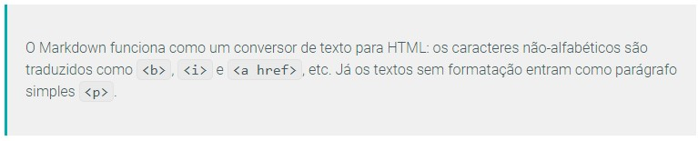

## Lista de comandos em Markdown Veja abaixo uma lista dos comandos em markdown e alguns exemplos de seu uso:

TITULAÇÃO

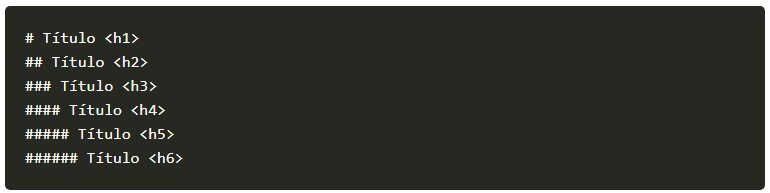

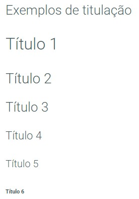

## 1.2 Ênfase

Para adicionar ênfase ao conteúdo que será escrito, usa-se o asterisco ou traço-baixo (underline)

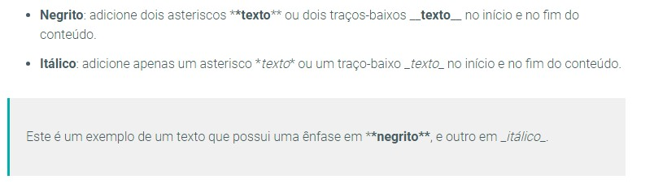

## 1.3 Links

Existem duas formas de inserir link em Markdown, através de um link **direto** ou usando um **texto-âncora**:

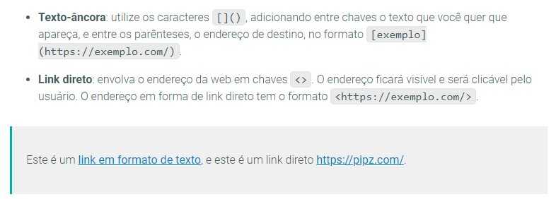

## 1.4 Lista de itens

Para listas não ordenadas, utilize um asterisco na frente to item da lista:

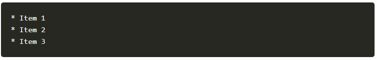

Para listas ordenadas, utilize o número do item seguido de ponto

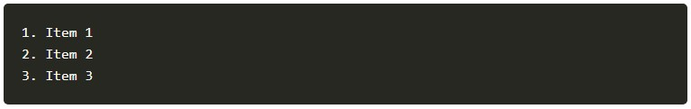

## 1.5 Imagens

O código para inserir uma imagem no conteúdo é semelhante ao código de inserir links-âncora, adicionando um ponto de exclamação no início do código, como no exemplo abaixo:

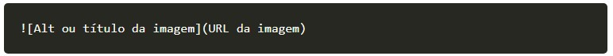

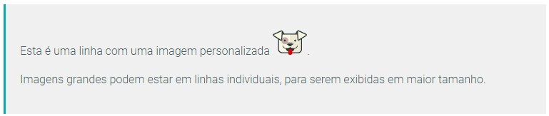

## 1.6 Citação (Quote)

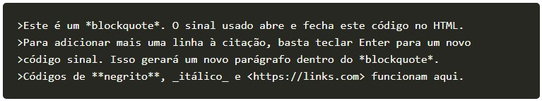

Como aparece no HTML:

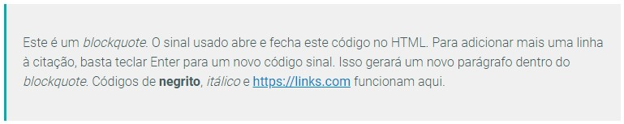

## 1.7 Código (Code Highlight)

Há dois modos de adicionar trechos de código ao Markdown:

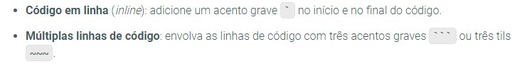

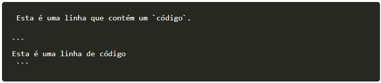

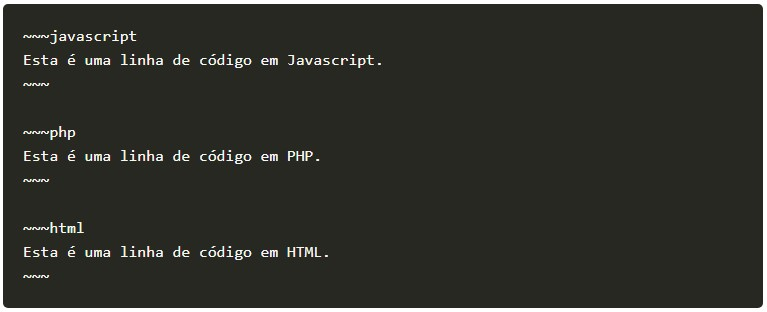

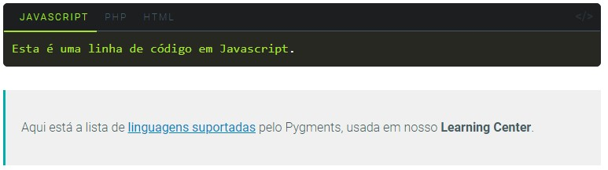

## 1.8 Tabela

Escolha os títulos das colunas e use | para delimitar as colunas. Depois, utilize hífen - na segunda linha para indicar que acima estão os títulos das colunas, usando novamente o | para delimitar colunas. Veja um exemplo abaixo:

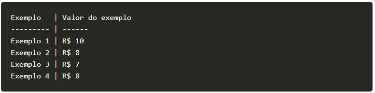

Como aparece no **Learning Center**:

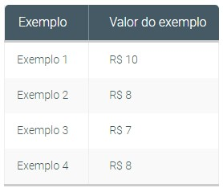

## 1.9 Próximos passos

- https://docs.pipz.com/central-de-ajuda/learning-center/criacao-e-gerenciamento/
- https://docs.pipz.com/central-de-ajuda/learning-center/importacaoexportacao/
- https://docs.pipz.com/central-de-ajuda/learning-center/personalizacao/
- https://docs.pipz.com/central-de-ajuda/learning-center/configuracao-de-seo/

# 2 Latex

## 2.1 O que é o LaTex?

LaTeX é um sistema ou programa de marcação para a editoração de documentos de alta qualidade tipográfica, específico para a elaboração de textos científicos. Trata-se de um conjunto de macros ou marcações para o processador de textos TeX.

Contudo, antes de pensar em desinstalar algum programa, um aviso: o LaTeX não é um processador de texto do tipo OpenOffice ou o Word do Office.

## 2.2 Formatação LaTex.

Ao contrário dos sistemas WYSIWYG, o conceito do LaTeX é visualizar a apresentação do resultado final do texto apenas após a preparação do mesmo, evitando assim distracções quanto à forma durante a preparação do conteúdo.

Depois de produzido o documento é possível obtê-lo em diversos formatos entre eles os formatos PDF, PS, HTML, ABNT, duas colunas e muito mais.

## 2.3 Vantagens em usar o editor LaTec.

- Algoritmo avançado do TeX, que permite criar documentos de aparência verdadeiramente profissional;
- Ausência de bugs;
- Encoraja as pessoas a concentrar suas atenções no conteúdo e na distribuição lógica das ideias, e não na aparência;
- As versões dos arquivos na plataforma não sofrem de incompatibilidade. Ou seja, um arquivo salvo em TeX, no dia da sua criação em 1978 – sim, ele é um senhor já – pode ser acessado e aberto hoje sem qualquer problema;
- Os documentos em TeX são leves e de fácil exportação;
- É possível utilizar o LaTeX sem efetivamente aprender muitos comandos;
- Edição de fórmulas matemáticas robusta e apresentação visualmente agradável;
- Estruturas tipográficas complexas como bibliografia, tabela de conteúdo e citações estão abstraídas, podendo ser geradas facilmente e de forma consistente ao longo do documento;
- É possível editar e imprimir mesmo em um computador remoto, através de uma sessão SSH ou telnet. O processador também não precisa trabalhar durante o tempo todo para criar a formatação do documento;
- Ideal para documentos com grande número de páginas, devido à maior leveza dos documentos de edição (documento de texto) e à maior confiança proporcionada ao nível da formatação;
- Templates mais consistentes e seguros;
- Possibilidade de incorporação vídeos, áudio e animações.

## 2.4 Como usar o editor LaTex.

Os documentos escritos para o LaTeX estão em texto simples, sem qualquer formatação. Nesse sentido, é possível escrever documentos para o LaTeX em qualquer editor de texto, mesmo nos mais simples graficamente, como o Vi ou o Bloco de Notas. No entanto recomenda-se a utilização de programas específicos, muitos deles software livre.

## 2.5 OverLeaf

[OverLeaf](https://pt.overleaf.com/) é uma ótima ferramenta de edição de LaTeX online é o Overleaf. Entre os principais recursos do Overleaf estão a capacidade de colaborar com os membros de sua equipe em trabalhos técnicos ou acadêmicos em tempo real.

## 2.6 TeXMaker.

[TeXmaker](https://www.xm1math.net/texmaker/) é uma das mais populares soluções multi-plataforma de código aberto para edição de LaTeX. Esta ferramenta está disponível para todas as plataformas principais e possui recursos que são um ótimo caso para qualquer editor de texto LaTeX.

## 2.7 TeXnicCenter

[TeXnicCenter](https://www.texniccenter.org/) é outro grande editor LaTeX desenvolvido especificamente para o sistema operacional Windows. Por ser executado no Windows, o TeXnicCenter usa a distribuição de composição tipográfica MiKTeX da Microsoft, o que torna mais fácil para o Microsoft Word processar documentos LaTeX.

## 2.8 LyX

LyX é um editor de código aberto que está entre os editores de LaTeX mais populares no momento, com suporte para muitos recursos modernos e exclusivos. Ele enfatiza a abordagem de escrita WYSIWYM, com uma interface simples baseada em GUI.

## 2.9 TeXstudio

[TeXstudio](https://texstudio.sourceforge.net/) é outro editor de LaTeX de código aberto e multiplataforma, bastante popular entre a academia. Embora a interface possa parecer muito semelhante ao TeXmaker, recursos adicionais como contagem de palavras de documento, análise de contagem de frequência e muito mais o tornaram uma ferramenta de edição LaTeX completa e independente.